# Predictive Modeling on Credit Data

## Background

- Predictive modeling techniques can be used to make accurate prediction about a response given some inputs.
- We want to find out how to predict credit card balance given various facts about an individual.

## Data

- **Credit** dataset
- 400 observations
- Data on credit card balance and 10 predictors:
  - age
  - number of credit cards
  - years of education
  - income
  - credit limit
  - credit rating
  - gender
  - student status
  - marital status
  - ethnicity

## Goal

- Use different regression techiques and find the best fitting model to most accurately predict the credit card balance of an individual.
- Which of these 10 variables are useful in predicting balance?

## Methods

- Ordinary least squares model may have issues of high variance and thus poor prediction accuracy. It may also be hard to interpret since it does not remove irrelevant variables.
- We use four different regression techniques in addition to OLS that may improve on prediction accuracy and interpretability.
  - Ridge regression (RR)
  - Lasso regression (LR)
  - Principal components regression (PCR)
  - Partial least squares regression (PLSR)

## Methods

- Assume linear relationship between predictors and response \[ \begin{aligned} Credit_i = \beta_0 + \beta_1X_i + \beta_2X_i + \ldots + \beta_{10}X_i + \epsilon_i \end{aligned} \]
- Where \(\beta_0\) is the intercept and \(\beta_1\), …, \(\beta_{10}\) are the regression coefficients for their associated predictor, and \(\epsilon\) is the error term.

## Methods - OLS

- OLS tries estimate the coefficients by minimizing residual sum of squares (RSS). \[ \begin{aligned} RSS = \sum_{i=1}^{n} (y_i - \beta_0 - \sum_{j=1}^{p} \beta_jx_{ij})^2 \end{aligned} \]
- We use OLS as a benchmark for the other techniques.

## Methods - Ridge and Lasso

- Known as shrinkage methods, ridge and lasso minimize respectively \[ \begin{aligned} RSS + \lambda \sum_{j=1}^{p} \beta_j^2 \end{aligned} \] \[ \begin{aligned} RSS + \lambda \sum_{j=1}^{p} |\beta_j| \end{aligned} \]
- Both include shrinkage penalty. As \(\lambda\) grows larger, coefficients shrink. Lasso can shrink coefficients to exactly zero while ridge cannot.
- Find the \(\lambda\) that minimizes mean squared error in model.

## Methods - PCR and PLSR

- Known as dimension reduction methods
- Mitigates overfitting
- PCR tries to explain similar groups of predictor variables using a number of components less than the original number of predictors.
- PLSR tries to do the same except also considers the relation to the response.
- Find the number of components \(M\) that minimizes mean squared error in model.

## Results

Coefficient Table of Regression Models

|  | OLS | Ridge | Lasso | PCR | PLSR |
| --- | --- | --- | --- | --- | --- |
| Income | -0.598 | -0.569 | -0.552 | -0.599 | -0.599 |
| Limit | 0.958 | 0.719 | 0.925 | 0.671 | 0.676 |
| Rating | 0.382 | 0.593 | 0.368 | 0.671 | 0.666 |
| Cards | 0.053 | 0.044 | 0.045 | 0.040 | 0.041 |
| Age | -0.023 | -0.025 | -0.017 | -0.023 | -0.023 |
| Education | -0.007 | -0.006 | 0.000 | -0.006 | -0.006 |

## Results

Coefficient Table of Regression Models (cont.)

|  | OLS | Ridge | Lasso | PCR | PLSR |
| --- | --- | --- | --- | --- | --- |
| GenderFemale | -0.012 | -0.011 | 0.000 | -0.012 | -0.012 |
| StudentYes | 0.278 | 0.273 | 0.267 | 0.276 | 0.277 |
| MarriedYes | -0.009 | -0.011 | 0.000 | -0.011 | -0.011 |
| EthnicityAsian | 0.016 | 0.016 | 0.000 | 0.017 | 0.019 |
| EthnicityCaucasian | 0.011 | 0.011 | 0.000 | 0.011 | 0.013 |

## Results

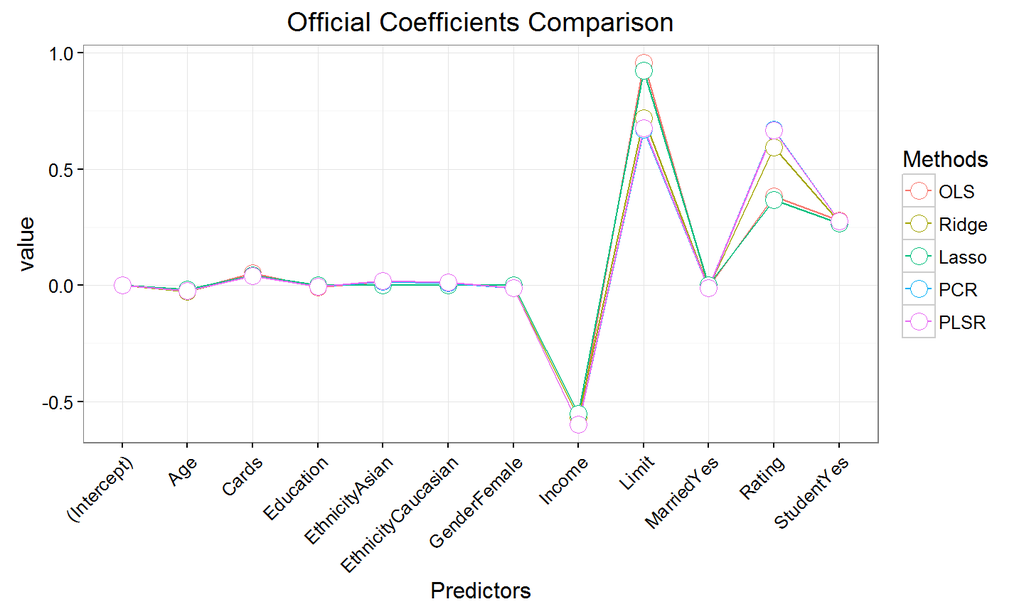

## Results

Mean squared errors of each model

|  | Ridge | Lasso | PCR | PLSR |
| --- | --- | --- | --- | --- |
| MSE Value | 0.04544 | 0.04676 | 0.04601 | 0.04658 |

Our tests find that ridge regression has the lowest MSE.

Thus, we consider ridge regression as our best performing model and use it for our official coefficients.

## Conclusions

- Strong predictors of credit balance include
  - Income (-0.57)
  - Credit Limit (0.72)
  - Credit Rating (0.59)
  - Student Status (0.27)
- Meanwhile, number of cards, age, education, gender, marital status, and ethnicity are relatively weak predictors.
- All four regression models have competitive MSEs, but ridge regression has the smallest.
- Low MSE implies our predictions should be quite accurate.